# 算法训练营Day 32 - Dynamic Programming

Author

Siru Wu

Published

March 1, 2026

今天开始动态规划（Dynamic Programming），简称DP！

对于动态规划问题，将拆解为如下五步曲，这五步都搞清楚了，才能说把动态规划真的掌握了！

1. 确定dp数组（dp table）以及下标的含义
2. 确定递推公式
3. dp数组如何初始化
4. 确定遍历顺序
5. 举例推导dp数组

## [509. 斐波那契数](https://leetcode.cn/problems/fibonacci-number/description/)

> 斐波那契数 （通常用 F(n) 表示）形成的序列称为 斐波那契数列 。该数列由 0 和 1 开始，后面的每一项数字都是前面两项数字的和。也就是：
> - F(0) = 0，F(1) = 1
> - F(n) = F(n - 1) + F(n - 2)，其中 n > 1

> 给定 n ，请计算 F(n) 。

> **示例 1：**
> - 输入：n = 2
> - 输出：1
> - 解释：F(2) = F(1) + F(0) = 1 + 0 = 1

> **示例 2：**
> - 输入：n = 3
> - 输出：2
> - 解释：F(3) = F(2) + F(1) = 1 + 1 = 2

> **示例 3：**
> - 输入：n = 4
> - 输出：3
> - 解释：F(4) = F(3) + F(2) = 2 + 1 = 3

```python
class Solution:
    def fib(self, n: int) -> int:
        if n == 0:
            return 0

        dp = [0] * (n + 1)

        dp[0] = 0
        dp[1] = 1

        for i in range(2, n + 1): # 我们前面已经定义了dp[0]和dp[1]，所以for range里面要从2开始到n + 1,也就是dp[n]的位置
            dp[i] = dp[i - 1] + dp[i - 2]

        return dp[n]
```

## [70. 爬楼梯](https://leetcode.cn/problems/climbing-stairs/description/)

> 假设你正在爬楼梯。需要 n 阶你才能到达楼顶。

> 每次你可以爬 1 或 2 个台阶。你有多少种不同的方法可以爬到楼顶呢？

> **示例 1：**
> - 输入：n = 2
> - 输出：2
> - 解释：有两种方法可以爬到楼顶。
> - 1. 1 阶 + 1 阶
> - 2. 2 阶

> **示例 2：**
> - 输入：n = 3
> - 输出：3
> - 解释：有三种方法可以爬到楼顶。
> - 1. 1 阶 + 1 阶 + 1 阶
> - 2. 1 阶 + 2 阶
> - 3. 2 阶 + 1 阶

```python
class Solution:
    def climbStairs(self, n: int) -> int:
        if n <= 1:
            return n

        dp = [0] * (n + 1)
        dp[1] = 1
        dp[2] = 2

        for i in range(3, n + 1):
            dp[i] = dp[i - 1] + dp[i - 2]

        return dp[n]
```

## [746. 使用最小花费爬楼梯](https://leetcode.cn/problems/min-cost-climbing-stairs/description/)

> 给你一个整数数组 cost ，其中 cost[i] 是从楼梯第 i 个台阶向上爬需要支付的费用。一旦你支付此费用，即可选择向上爬一个或者两个台阶。

> 你可以选择从下标为 0 或下标为 1 的台阶开始爬楼梯。

> 请你计算并返回达到楼梯顶部的最低花费。

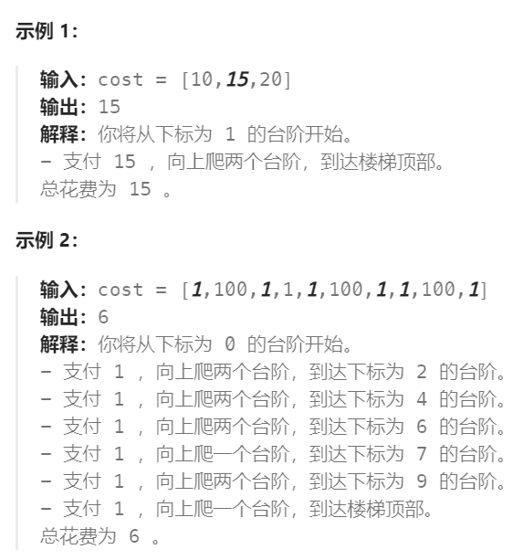

```python
class Solution:
    def minCostClimbingStairs(self, cost: List[int]) -> int:
        dp = [0] * (len(cost) + 1)
        dp[1] = 0
        dp[0] = 0

        for i in range(2, len(cost) + 1):
            dp[i] = min(dp[i - 1] + cost[i - 1], dp[i - 2] + cost[i - 2])

        return dp[len(cost)]
```